# Folketingvalg 1973-2022

Kristian Krabbe

2023-12-19

# Installing packages and libraries

```r
library(tidyverse)
```

```r
library(ggplot2)
```

# Importing the dataset into R

```r
folketingsvalg <- read_csv("data/folketingsvalg.csv")
ftv_clean <- na.omit(folketingsvalg)
```

By using na.omit, I remove the cells in my dataset where NA (not available) occurs. So my clean dataset is named ftv_clean (ftv = short for folketingsvalg)

Then I use str() to inspect my dataset

```r
str(ftv_clean)
```

```
## tibble [208 × 3] (S3: tbl_df/tbl/data.frame)
##  $ Party        : chr [1:208] "Socialdemokratiet" "Socialdemokratiet" "Socialdemokratiet" "Socialdemokratiet" ...
##  $ Election_year: num [1:208] 1973 1975 1977 1979 1981 ...
##  $ Procent      : num [1:208] 25.6 29.9 37 38.3 32.9 31.6 29.3 29.8 37.4 34.6 ...
##  - attr(*, "na.action")= 'omit' Named int [1:152] 68 69 70 71 72 80 82 83 84 85 ...
##   ..- attr(*, "names")= chr [1:152] "68" "69" "70" "71" ...
```

str() do it possible for me to see that my clean dataset have 208 observation of 3 varables, which is “Party”, “Election_year” and “Procent”

# Visualization of my dataset

By plotting my whole dataset, it gives me at overview on how each parties’ development of percentage of votes has been in the periode of 1973 until 2022. I use the geom_line() to make the visualization.

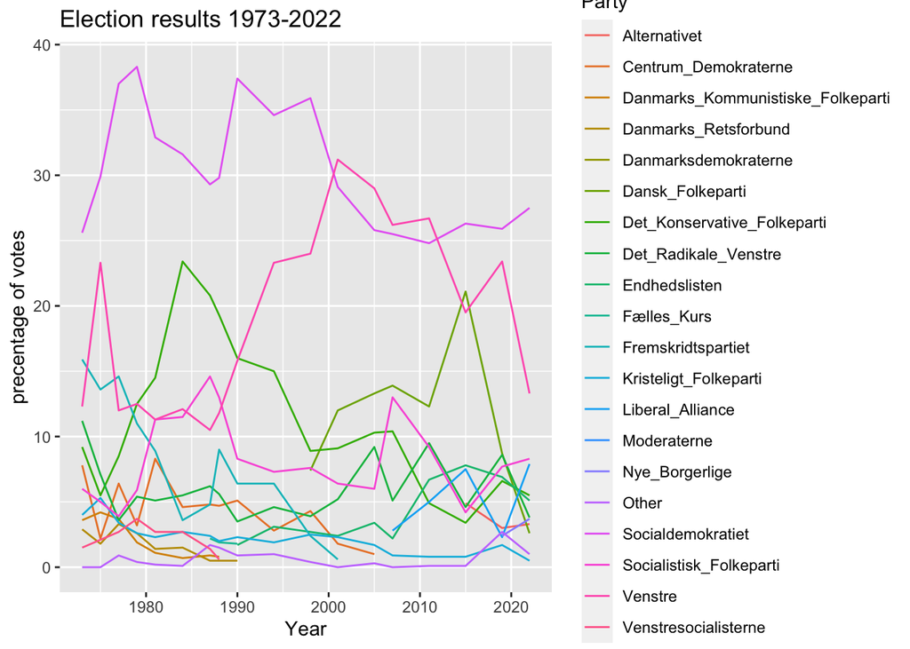

```r
ftv_clean %>%
  ggplot(aes(x = Election_year,y = Procent))+
  geom_line(aes(color = Party))+
  labs(x = "Year", y = "precentage of votes",
       title = "Election results 1973-2022" )
```

- The party Kristeligt Folkeparti changes its name to Kristendemokraterne in 2003, but to make it easier, the party is simply called the Kristeligt Folkeparti throughout the entire dataset.

# Plotting the parties related to ‘Jordskredsvalget’ in 1973

Then I use ggplot() to make graph for the parties.

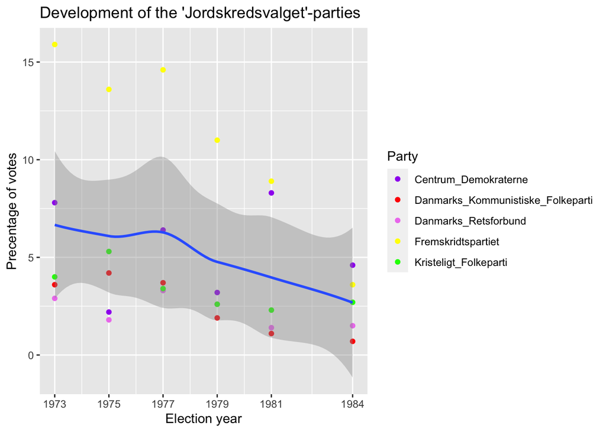

```r
parties_to_plot <- c("Centrum_Demokraterne", "Fremskridtspartiet", "Kristeligt_Folkeparti",
                     "Danmarks_Retsforbund", "Danmarks_Kommunistiske_Folkeparti")
custom_colors <- c("Centrum_Demokraterne" = "purple", "Fremskridtspartiet" = "yellow",
                   "Kristeligt_Folkeparti" = "green", "Danmarks_Retsforbund" = "violet",
                   "Danmarks_Kommunistiske_Folkeparti" = "red")
years_to_include <- c(1973, 1975, 1977, 1979, 1981, 1984)

filtered_data <- ftv_clean %>%
  filter(Party %in% parties_to_plot & Election_year %in% years_to_include)

ggplot(filtered_data, aes(x = Election_year,y = Procent)) +
  geom_point(aes(color = Party)) +
  geom_smooth()+
  scale_color_manual(values = custom_colors)+
  labs(title = "Development of the 'Jordskredsvalget'-parties",
       x = "Election year",
       y = "Precentage of votes")+
  scale_x_continuous(breaks = years_to_include)
```

# The four old parties

I do the same thing as before, just this time I will look at the four old/traditional parties Socialdemokratiet, Venstre, Det Radikale Venstre og Det Konservative Folkeparti. Again, I give the parties a color that represents their party’s color I’m using ggplot() again to make the graph for the parties.

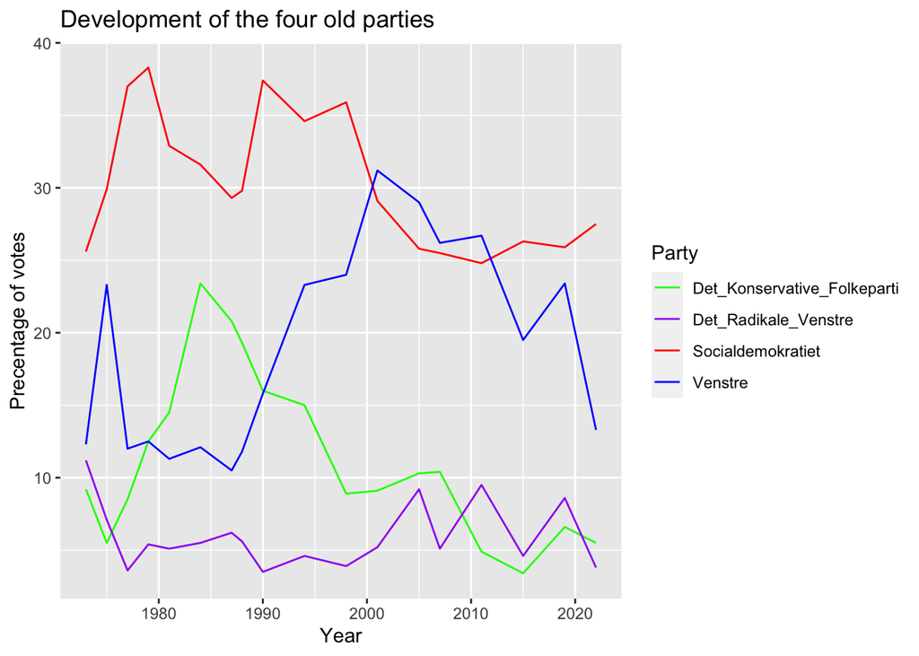

```r
parties_to_plot2 <- c("Socialdemokratiet", "Venstre", "Det_Radikale_Venstre", "Det_Konservative_Folkeparti")

custom_colors <- c("Socialdemokratiet" = "red", "Venstre" = "blue", "Det_Radikale_Venstre" = "purple", "Det_Konservative_Folkeparti" = "green")

filtered_data2 <- ftv_clean %>% filter(Party %in% parties_to_plot2)

ggplot(filtered_data2, aes(x = Election_year, y = Procent)) +
  geom_line(aes(color = Party)) +
  scale_color_manual(values = custom_colors)+
  labs(title = "Development of the four old parties",
       x = "Year",
       y = "Precentage of votes")
```

# Comparison of the average voting percentage for the right-wing and left-wing

```r
left_wing <- ftv_clean %>%
  filter(Party == "Socialdemokratiet" | Party == "Socialistisk_Folkeparti" | Party == "Endhedslisten" |
           Party == "Alternativet" | Party == "Danmarks_Kommunistiske_Folkeparti" |
           Party == "Fælles_Kurs" | Party == "Venstresocialisterne")
```

```r
right_wing <- ftv_clean %>%
  filter(Party == "Venstre" | Party == "Det_Konservative_Folkeparti" | Party == "Centrum_Demokratern" |
           Party == "Fremskridtspartiet" | Party == "Kristeligt_Folkeparti" | Party == "Danmarks_Retsforbund" |
           Party == "Dansk_Folkepart" | Party == "Liberal_Alliance" | Party == "Moderaterne" |
           Party == "Nye_Borgerlige" | Party == "Danmarksdemokraterne")
```

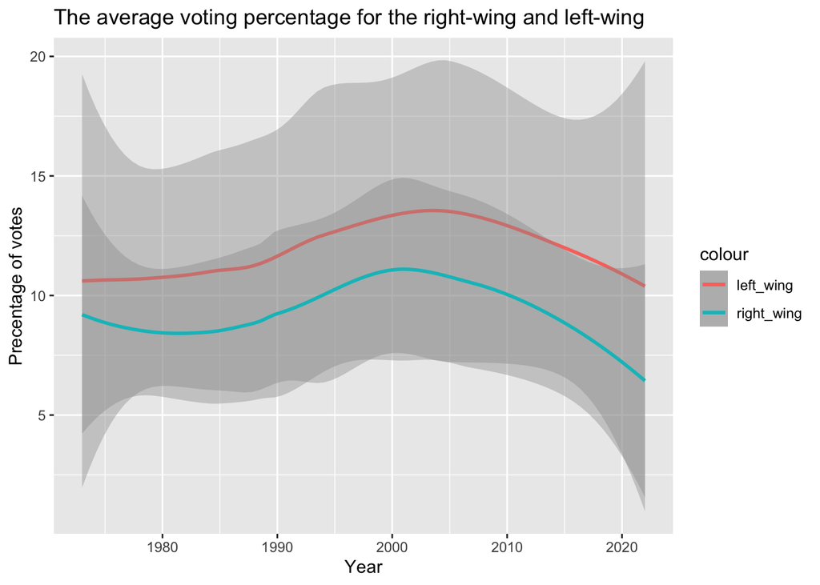

```r
ggplot()+
  geom_smooth(data = left_wing, aes(x = left_wing$Election_year, y = left_wing$Procent, color = "left_wing"))+
  geom_smooth(data = right_wing, aes(x = right_wing$Election_year, y = right_wing$Procent, color = "right_wing"))+
  labs(x = "Year", y = "Precentage of votes", title = "The average voting percentage for the right-wing and left-wing")
```